# Statistical Inference: Analysis of the “ToothGrowth” Dataset

Vasilena Taralova

January 29, 2017

# 1 Introduction

The goal of this project is to analyze the “ToothGrowth” data from the R “datasets” package. The collected data in the “ToothGrowth” data frame is about the effect of vitamin C intake on tooth growth in guinea pigs. We perform some basic exploratory data analysis and construct confidence intervals and hypothesis tests to investigate what is the impact of different vitamin C delivery methods and dosage on tooth growth in guinea pigs.

First we load the libraries that we will need:

```r
library(ggplot2)
library(datasets)
library(plotly)
```

# 2 Exploratory data analysis

We begin with a summary of the data. We see that there are three variables in the data frame. The first one is “len” - the tooth length, the next is “supp”, which is the type of supplement/delivery method, and the last one is “dose”, which is the dosage of vitamin C. Tooth length and “dose” are numeric variables, whereas the type of supplement - “supp”, is a factor. The mean tooth length is 18.81 and we observe that 30 subjects were given orange juice (OJ), and 30 - ascorbic acid (VC):

```r
head(ToothGrowth)
```

```
   len supp dose
1  4.2   VC  0.5
2 11.5   VC  0.5
3  7.3   VC  0.5
4  5.8   VC  0.5
5  6.4   VC  0.5
6 10.0   VC  0.5
```

```r
summary(ToothGrowth)
```

```
      len        supp         dose
 Min.   : 4.20   OJ:30   Min.   :0.500
 1st Qu.:13.07   VC:30   1st Qu.:0.500
 Median :19.25           Median :1.000
 Mean   :18.81           Mean   :1.167
 3rd Qu.:25.27           3rd Qu.:2.000
 Max.   :33.90           Max.   :2.000
```

Below we see that the mean tooth length of subjects that were given orange juice is 20.66 compared to 16.96 for subjects that were given ascorbic acid. This motivates us to later test the hypothesis that vitamin C intake in the form of orange juice leads to a greater mean tooth growth in guinea pigs compared to vitamin C intake in the form of ascorbic acid.

```r
summary(subset(ToothGrowth, ToothGrowth$supp == "OJ")$len)
```

```
   Min. 1st Qu.  Median    Mean 3rd Qu.    Max.
   8.20   15.52   22.70   20.66   25.72   30.90
```

```r
summary(subset(ToothGrowth, ToothGrowth$supp == "VC")$len)
```

```
   Min. 1st Qu.  Median    Mean 3rd Qu.    Max.
   4.20   11.20   16.50   16.96   23.10   33.90
```

In order to better illustrate the relationship between the type of supplement intake and the dosage of vitamin C on tooth growth, we show several box plots. First we show a box plot of tooth length by dose and supplement type. From the box plot we can see that the mean (the red dots) and median (the horizontal black lines) tooth length is getting larger as the dose of vitamin C increases. We also observe that within doses 0.5 and 1 the mean tooth length is larger for the orange juice (OJ) type of delivery method compared to the ascorbic acid (VC). The plot is made with “plotly” and it is interactive. If one hovers with the mouse over the box plots, the mean value is displayed as well as the respective quantiles.

```r
g <- ggplot(data = ToothGrowth, aes(x = supp, y = len)) +
       geom_boxplot() +
       stat_summary(fun.y = mean,
                    geom = 'point',
                    shape = 16,
                    col = "red",
                    cex = 2) +
       facet_wrap(~dose) +
       scale_y_continuous(breaks = seq(0,40,5)) +
       ylab("Tooth length") +
       xlab("") +
       ggtitle("Box Plot of Tooth Growth by Dose and Supplement Type")


ggplotly(g)
```

[interactive chart not shown]

The next box plot displays tooth growth by type of supplement and dosage. Here we can see very clearly the dependence of tooth length on the amount of vitamin C taken. The higher the dosage of vitamin C, the bigger the tooth growth:

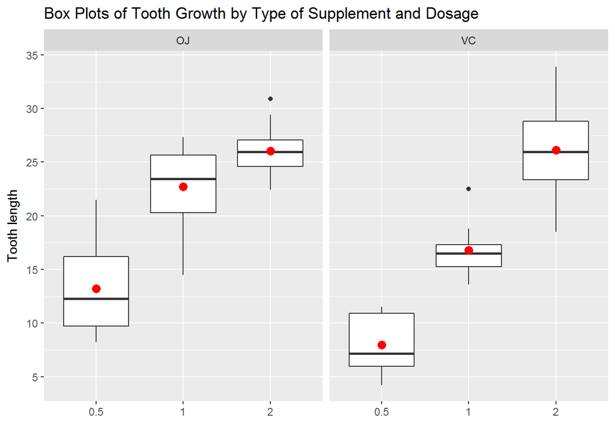

```r
ggplot(data = ToothGrowth, aes(x = factor(dose), y = len)) +
 geom_boxplot() +
 stat_summary(fun.y = mean,
              geom = 'point',
              shape = 16,
              col = "red",
              cex = 3) +
 facet_wrap(~supp) +
 scale_y_continuous(breaks = seq(0,40,5)) +
 ylab("Tooth length") +
 xlab("") +
 ggtitle("Box Plots of Tooth Growth by Type of Supplement and Dosage")
```

The next set of box plots shows tooth growth by dosage regardless of the type of delivery method. Again, we observe that higher amounts of vitamin C lead to greater tooth growth:

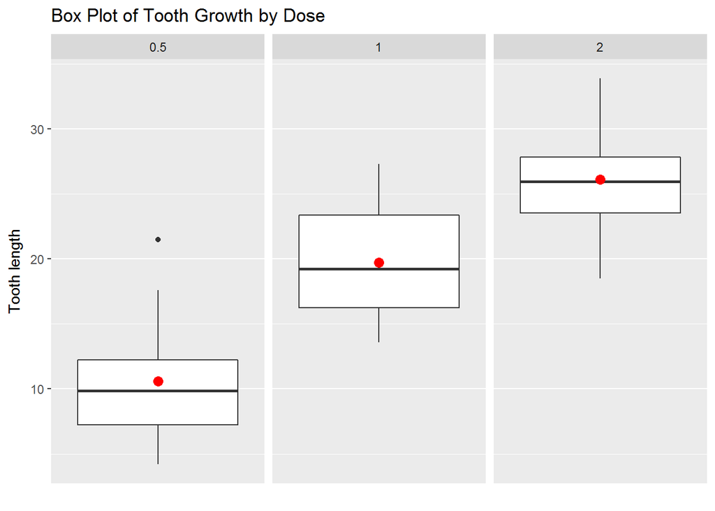

```r
ggplot(data = ToothGrowth, aes(x = factor(0), y = len)) +
 geom_boxplot() +
 stat_summary(fun.y = mean,
              geom = 'point',
              shape = 16,
              col = "red",
              cex = 3) +
 ylab("Tooth length") +
 xlab("") +
 ggtitle("Box Plot of Tooth Growth by Dose") +
 scale_x_discrete(breaks = NULL) +
 facet_wrap(~factor(ToothGrowth$dose))
```

The last box plot shows tooth growth by type of supplement. The plot is interactive and one can hover over it with the mouse to see the mean value and the quantiles. We see that the mean and median tooth length for orange juice as a type of supplement is bigger than that for ascorbic acid:

```r
g <- ggplot(data = ToothGrowth, aes(x = factor(0), y = len)) +
       geom_boxplot() +
       stat_summary(fun.y = mean,
                    geom = 'point',
                    shape = 16,
                    col = "red",
                    cex = 3) +
       facet_wrap(~supp) +
       ylab("Tooth length") +
       xlab("") +
       ggtitle("Box Plot of Tooth Growth by Type of Supplement") +
       scale_x_discrete(breaks = NULL) +
       scale_y_continuous(breaks = seq(0,40,5))

ggplotly(g, tooltip = "y")
```

[interactive chart not shown]

# 3 Hypothesis testing and confidence intervals

In this section we test hypotheses and construct confidence intervals about different population means. We consider a variety of populations of guinea pigs based on the type of delivery method of vitamin C, as well as the dosage of vitamin C. For example, we build a confidence interval for the population mean of tooth length in the population of guinea pigs that receive vitamin C in the form of orange juice. We also construct a confidence interval for the population mean of tooth length in the population of guinea pigs that receive vitamin C in the form of ascorbic acid, and so on.

For small samples ($n<30$, where $n$ is the number of observations) the Central Limit Theorem (CLT) does not hold (meaning that the large sample mean is not approximately normally distributed), and Student’s t distribution must be used for constructing confidence intervals and testing hypotheses about population means. The t distribution assumes that the data are approximately normally distributed. The t distribution is similar to the standard normal distribution but takes a slightly different shape depending on the sample size. t-confidence intervals are larger for smaller samples, resulting in larger margins of error, because small samples are less precise.

$$T = \dfrac{\bar{X} - \mu}{s/\sqrt{n}}\sim t(n-1)$$

In the formula above $\displaystyle \bar{X}=\dfrac{1}{n}\sum\limits_{i=1}^n X_i$ is the sample mean and $\displaystyle s=\sqrt{\dfrac{1}{n-1}\sum\limits_{i=1}^{n}(X_i - \bar{X})^2}$ is the sample standard deviation. The corresponding 95% confidence interval is:

$$\bar{X}\pm t_{0.975,n-1}\dfrac{s}{\sqrt{n}}$$

Now we will consider the case when we want to test whether or not the difference in means of two independent populations is zero. Let us have a collection of $n_X$ independent and identically distributed (iid) observations $X_i$ from the first population, and a collection of $n_Y$ iid observations from the second population. Then $X_i\sim N(\mu_X, \sigma^2_X)$ and $Y_i\sim N(\mu_Y, \sigma^2_Y)$. If we want to test the hypotheses $H_0: \, \mu_X=\mu_Y$ versus one of the alternative hypotheses: $H_a: \, \mu_X<\mu_Y$, $H_a: \, \mu_X>\mu_Y$, or $H_a : \, \mu_X\neq\mu_Y$, we use the following test statistic
$$\displaystyle T=\dfrac{\bar{X}-\bar{Y} - \left( \mu_X - \mu_Y \right)}{\sqrt{\dfrac{s_X^2}{n_X} + \dfrac{s_Y^2}{n_Y}}},$$

which follows the Student’s t distribution with

$$\displaystyle r=\dfrac{\left(s_X^2/n_X + s_Y^2/n_Y \right)^2}{\left(\dfrac{s_X^2}{n_X}\right)^2/(n_X-1) + \left(\dfrac{s_Y^2}{n_Y}\right)^2/(n_Y-1)}$$

degrees of freedom, where $\displaystyle \bar{X}=\dfrac{1}{n_X}\sum\limits_{i=1}^{n_X} X_i$, $\displaystyle \bar{Y}=\dfrac{1}{n_Y}\sum\limits_{i=1}^{n_Y} Y_i$ are the sample means, and $\displaystyle s_X^2=\dfrac{1}{n_X - 1}\sum\limits_{i=1}^{n_X} (X_i - \bar{X})^2$ and $\displaystyle s_Y^2=\dfrac{1}{n_Y - 1}\sum\limits_{i=1}^{n_Y} (Y_i - \bar{Y})^2$ are the sample variances. The corresponding 95% t-confidence interval for $\mu_X-\mu_Y$ is:

$$\bar{X}-\bar{Y}\pm t_{0.975,r}\sqrt{\dfrac{s_X^2}{n_X} + \dfrac{s_Y^2}{n_Y}}$$

# 4 Confidence intervals

## 4.1 Tooth length by type of supplement

We construct 95% t-confidence intervals for the population mean of tooth length for each of the two types of supplements. We observe that the confidence interval for OJ is less spread out than that for VC. We also notice that there is an overlap between the two confidence intervals. Further on we will test the hypothesis if the two population means are equal.

### 4.1.1 Orange juice

We start with a confidence interval in the case of orange juice as a delivery method of vitamin C. First we show the normalized histogram of tooth length together with the respective normal and empirical probability density functions:

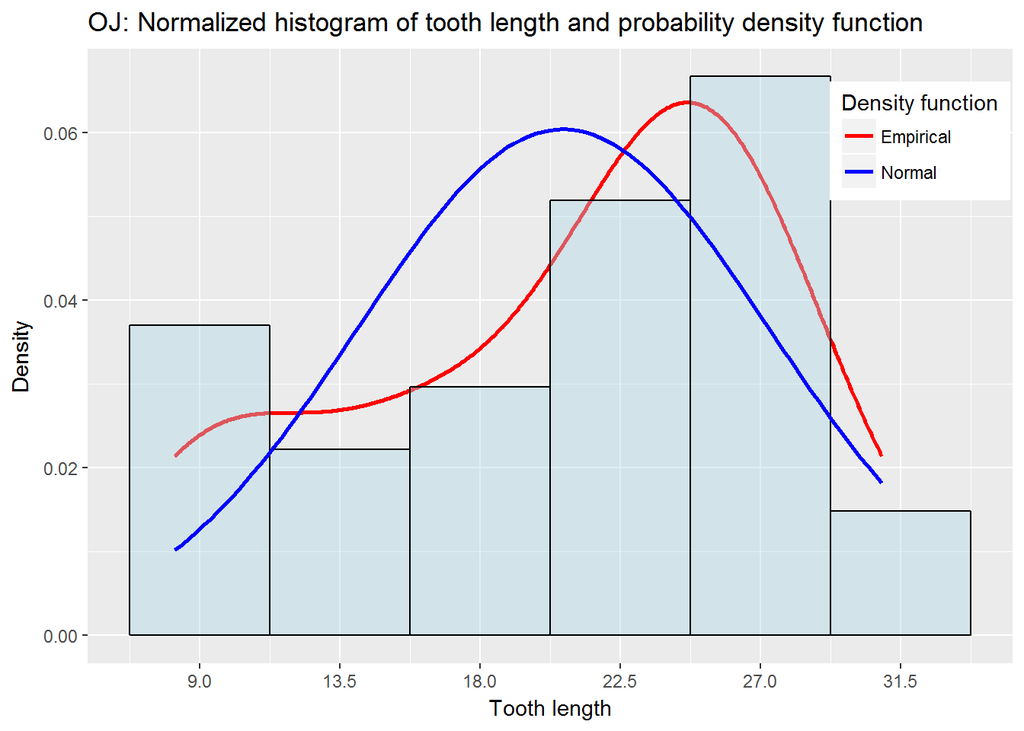

```r
df <- subset(ToothGrowth, ToothGrowth$supp == "OJ")

g <- ggplot(data = df, aes(x = df$len)) +
         geom_line(aes(y = ..density.., colour = "Empirical"),
                   stat = "density",
                   lwd = 1) +
         geom_histogram(aes(y = ..density..),
                        binwidth = 4.5,
                        colour = "black",
                        fill = "lightblue",
                        alpha = 0.4) +
         stat_function(fun = dnorm,
                       aes(colour = "Normal"),
                       args = list(mean = mean(df$len),
                                   sd = sd(df$len)),
                       lwd = 1) +
         scale_x_continuous(breaks = seq(0,35,4.5)) +
         scale_colour_manual(name = "Density function",
                             values = c("red", "blue")) +
         theme(legend.position = c(0.90, 0.85)) +
         labs(x = "Tooth length",
              y = "Density") +
         ggtitle("OJ: Normalized histogram of tooth length and probability density function")

g
```

```r
x <- subset(ToothGrowth, ToothGrowth$supp == "OJ")$len

test <- t.test(x = x,
               alternative = "two.sided",
               mu = mean(x),
               conf.level = 0.95)
```

The respective confidence interval for the population mean of tooth length is:

```r
test$conf.int
```

```
[1] 18.19678 23.12989
attr(,"conf.level")
[1] 0.95
```

### 4.1.2 Ascorbic acid

Next we calculate the 95% confidence interval for the population mean of tooth length in the case when the supplement type is ascorbic acid. Again we first show the normalized histogram of tooth length together with its respective normal and empirical probability density functions:

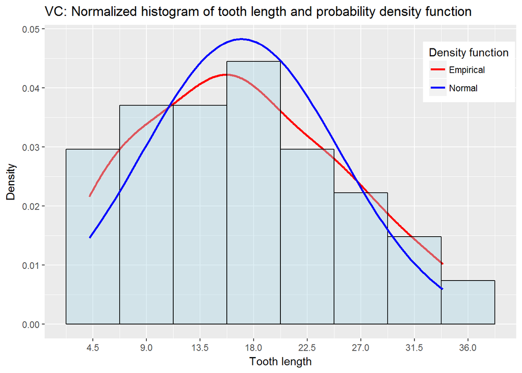

```r
df <- subset(ToothGrowth, ToothGrowth$supp == "VC")

g <- ggplot(data = df, aes(x = df$len)) +
         geom_line(aes(y = ..density.., colour = "Empirical"),
                   stat = "density",
                   lwd = 1) +
         geom_histogram(aes(y = ..density..),
                        binwidth = 4.5,
                        colour = "black",
                        fill = "lightblue",
                        alpha = 0.4) +
         stat_function(fun = dnorm,
                       aes(colour = "Normal"),
                       args = list(mean = mean(df$len),
                                   sd = sd(df$len)),
                       lwd = 1) +
         scale_x_continuous(breaks = seq(0,40,4.5)) +
         scale_colour_manual(name = "Density function",
                             values = c("red", "blue")) +
         theme(legend.position = c(0.90, 0.85)) +
         labs(x = "Tooth length",
              y = "Density") +
         ggtitle("VC: Normalized histogram of tooth length and probability density function")

g
```

Judging by the plot above, an assumption of normally distributed data seems reasonable. Hence, we build a 95% t-confidence interval:

```r
x <- subset(ToothGrowth, ToothGrowth$supp == "VC")$len

test <- t.test(x = x,
               alternative = "two.sided",
               mu = mean(x),
               conf.level = 0.95)
```

and the interval is:

```r
test$conf.int
```

```
[1] 13.87675 20.04992
attr(,"conf.level")
[1] 0.95
```

## 4.2 Tooth length by dosage

We construct a 95% t-confidence interval for the population mean of tooth length for each of the three dosages. We notice that the three confidence intervals do not overlap, and as the dosage increases, the confidence intervals are being shifted significantly to the right.

### 4.2.1 Dose of 0.5 mg/day vitamin C

Since we make the assumption that the data are normally distributed, below we display the normalized histogram of tooth length (for a dose of 0.5 mg/day vitamin C) together with its respective normal and empirical probability density functions:

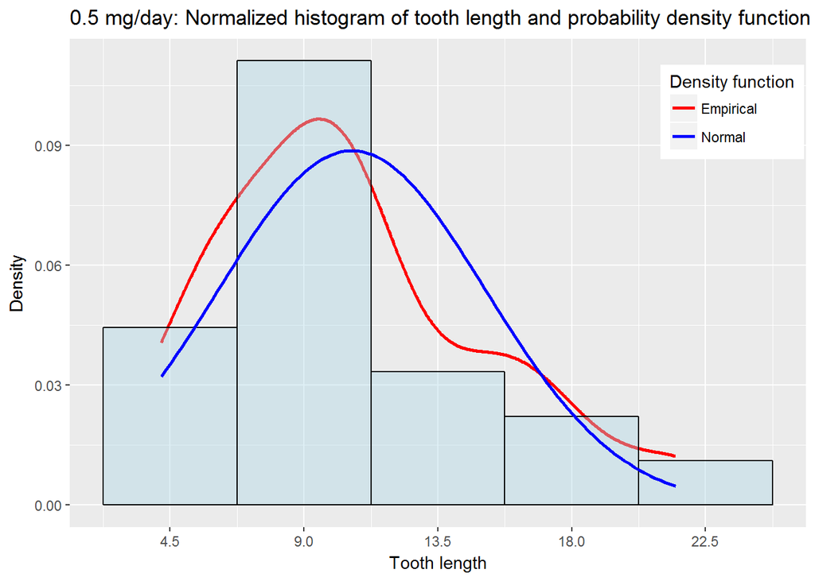

```r
df <- subset(ToothGrowth, ToothGrowth$dose == 0.5)

g <- ggplot(data = df, aes(x = df$len)) +
         geom_line(aes(y = ..density.., colour = "Empirical"),
                   stat = "density",
                   lwd = 1) +
         geom_histogram(aes(y = ..density..),
                        binwidth = 4.5,
                        colour = "black",
                        fill = "lightblue",
                        alpha = 0.4) +
         stat_function(fun = dnorm,
                       aes(colour = "Normal"),
                       args = list(mean = mean(df$len),
                                   sd = sd(df$len)),
                       lwd = 1) +
         scale_x_continuous(breaks = seq(0,30,4.5)) +
         scale_colour_manual(name = "Density function",
                             values = c("red", "blue")) +
         theme(legend.position = c(0.90, 0.85)) +
         labs(x = "Tooth length",
              y = "Density") +
         ggtitle("0.5 mg/day: Normalized histogram of tooth length and probability density function")

g
```

Since the normal distribution approximates well enough the empirical one, we can compute the t-confidence interval:

```r
x <- subset(ToothGrowth, ToothGrowth$dose == 0.5)$len

test <- t.test(x = x,
               alternative = "two.sided",
               mu = mean(x),
               conf.level = 0.95)
```

Then the respective confidence interval for the population mean of tooth growth for a dosage of 0.5 mg/day vitamin C is given below:

```r
test$conf.int
```

```
[1]  8.499046 12.710954
attr(,"conf.level")
[1] 0.95
```

### 4.2.2 Dose of 1 mg/day vitamin C

From the plot below we see that we can suppose that the tooth length for a dose of 1 mg/day vitamin C is roughly normally distributed:

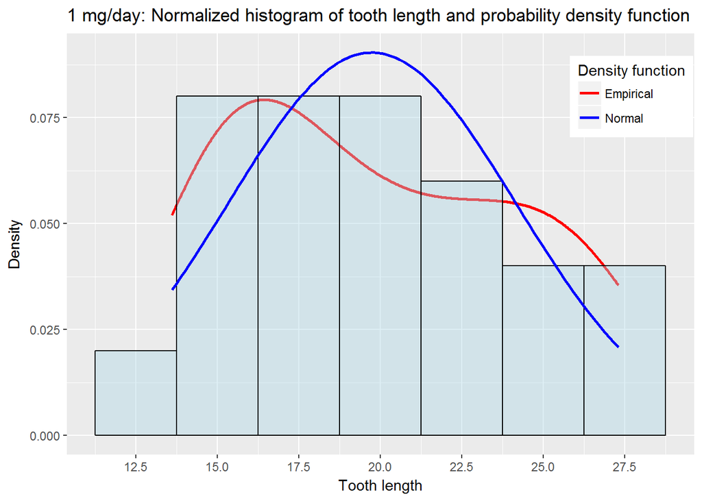

```r
df <- subset(ToothGrowth, ToothGrowth$dose == 1)

g <- ggplot(data = df, aes(x = df$len)) +
         geom_line(aes(y = ..density.., colour = "Empirical"),
                   stat = "density",
                   lwd = 1) +
         geom_histogram(aes(y = ..density..),
                        binwidth = 2.5,
                        colour = "black",
                        fill = "lightblue",
                        alpha = 0.4) +
         stat_function(fun = dnorm,
                       aes(colour = "Normal"),
                       args = list(mean = mean(df$len),
                                   sd = sd(df$len)),
                       lwd = 1) +
         scale_x_continuous(breaks = seq(0,30,2.5)) +
         scale_colour_manual(name = "Density function",
                             values = c("red", "blue")) +
         theme(legend.position = c(0.90, 0.85)) +
         labs(x = "Tooth length",
              y = "Density") +
         ggtitle("1 mg/day: Normalized histogram of tooth length and probability density function")

g
```

The respective confidence interval is calculated below:

```r
x <- subset(ToothGrowth, ToothGrowth$dose == 1)$len

test <- t.test(x = x,
               alternative = "two.sided",
               mu = mean(x),
               conf.level = 0.95)
```

The confidence interval for the population mean of tooth growth for a dosage of 1 mg/day vitamin C is:

```r
test$conf.int
```

```
[1] 17.66851 21.80149
attr(,"conf.level")
[1] 0.95
```

### 4.2.3 Dose of 2 mg/day vitamin C

From the figure below we see that the normal distribution is a good approximation of the empirical distribution of tooth length for a dose of 2 mg/day of vitamin C:

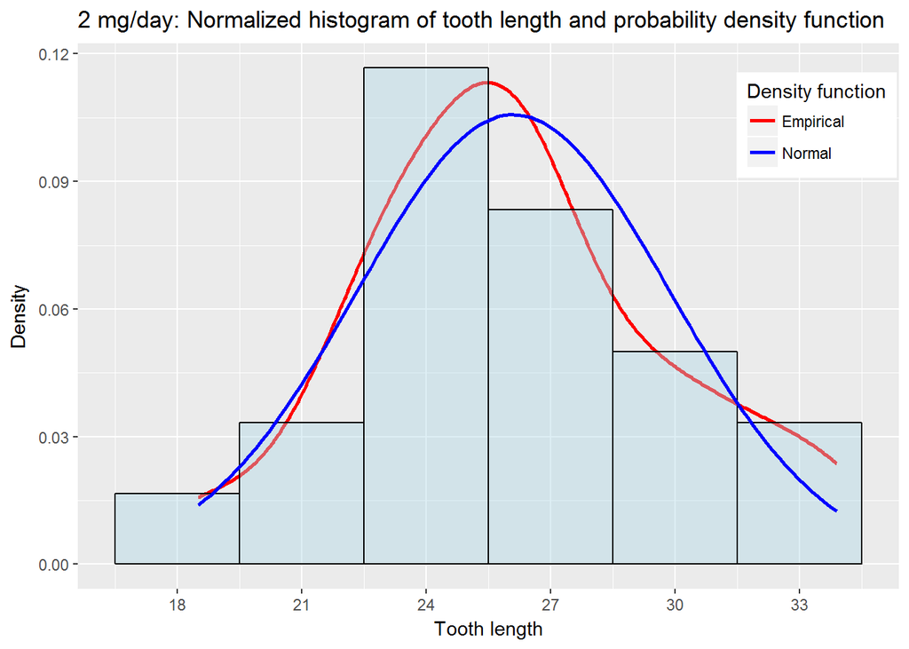

```r
df <- subset(ToothGrowth, ToothGrowth$dose == 2)

g <- ggplot(data = df, aes(x = df$len)) +
         geom_line(aes(y = ..density.., colour = "Empirical"),
                   stat = "density",
                   lwd = 1) +
         geom_histogram(aes(y = ..density..),
                        binwidth = 3,
                        colour = "black",
                        fill = "lightblue",
                        alpha = 0.4) +
         stat_function(fun = dnorm,
                       aes(colour = "Normal"),
                       args = list(mean = mean(df$len),
                                   sd = sd(df$len)),
                       lwd = 1) +
         scale_x_continuous(breaks = seq(0,35,3)) +
         scale_colour_manual(name = "Density function",
                             values = c("red", "blue")) +
         theme(legend.position = c(0.90, 0.85)) +
         labs(x = "Tooth length",
              y = "Density") +
         ggtitle("2 mg/day: Normalized histogram of tooth length and probability density function")

g
```

Therefore we can use Student’s t distribution to construct a confidence interval for the population mean:

```r
x <- subset(ToothGrowth, ToothGrowth$dose == 2)$len

test <- t.test(x = x,
               alternative = "two.sided",
               mu = mean(x),
               conf.level = 0.95)
```

The confidence interval for the population mean of tooth growth for a dosage of 2 mg/day vitamin C is:

```r
test$conf.int
```

```
[1] 24.33364 27.86636
attr(,"conf.level")
[1] 0.95
```

# 5 Hypothesis testing

## 5.1 Tooth growth by dose

### 5.1.1 Dose of 0.5 mg/day versus a dose of 1 mg/day

For **dose=0.5** and **dose=1** we want to test the following hypothesis: $H_0: \, \mu_{X}=\mu_{Y}$, versus $H_a: \, \mu_{X} < \mu_{Y}$, where $X_i$ is the tooth growth of the $i$-th subject for a dose of 0.5 mg/day vitamin C (regardless of the supplement type) and $Y_i$ is the tooth growth of the $i$-th subject for a dose of 1 mg/day vitamin C (regardless of the supplement type). We assume that $X_i\sim N(\mu_X, \sigma^2_X)$ and $Y_i\sim N(\mu_Y, \sigma^2_Y)$. We have a random sample of 20 subjects for both populations:

```r
nrow(subset(ToothGrowth, ToothGrowth$dose == 0.5))
```

```
[1] 20
```

```r
nrow(subset(ToothGrowth, ToothGrowth$dose == 1))
```

```
[1] 20
```

Below we perform the hypothesis test:

```r
x <- subset(ToothGrowth, ToothGrowth$dose == 0.5)$len
y <- subset(ToothGrowth, ToothGrowth$dose == 1)$len

test <- t.test(x = x, y = y,
               alternative = "less",
               mu = 0,
               paired = FALSE,
               var.equal = FALSE,
               conf.level = 0.95)
```

We reject the null hypothesis in favour of the alternative hypothesis, because the p-value is less than the significance level (type I error), which we set to 0.05:

```r
test$p.value
```

```
[1] 6.341504e-08
```

If we perform a two-sided hypothesis test

```r
test <- t.test(x = x, y = y,
               alternative = "two.sided",
               mu = 0,
               paired = FALSE,
               var.equal = FALSE,
               conf.level = 0.95)
```

we can obtain a 95% confidence interval for the difference in means $\mu_X-\mu_Y$:

```r
test$conf.int
```

```
[1] -11.983781  -6.276219
attr(,"conf.level")
[1] 0.95
```

### 5.1.2 Dose of 1 mg/day versus a dose of 2 mg/day

For **dose=1** and **dose=2** we test the following hypothesis: $H_0: \, \mu_{X}=\mu_{Y}$, versus $H_a: \, \mu_{X} < \mu_{Y}$, where $X_i$ is the tooth growth of the $i$-th subject for a dose of 1 mg/day vitamin C (regardless of the supplement type) and $Y_i$ is the tooth growth of the $i$-th subject for a dose of 2 mg/day vitamin C (regardless of the supplement type). The relevant R code is given below:

```r
x <- subset(ToothGrowth, ToothGrowth$dose == 1)$len
y <- subset(ToothGrowth, ToothGrowth$dose == 2)$len

test <- t.test(x = x, y = y,
               alternative = "less",
               mu = 0,
               paired = FALSE,
               var.equal = FALSE,
               conf.level = 0.95)
```

We reject the null hypothesis in favour of the alternative hypothesis at the 0.05 significance level, because the p-value is less than 0.05:

```r
test$p.value
```

```
[1] 9.532148e-06
```

## 5.2 Tooth growth by type of supplement

We want to test the hypothesis $H_0: \, \mu_{X}=\mu_{Y}$, versus $H_a: \, \mu_{X} > \mu_{Y}$, where $X_i$ is the tooth growth of the $i$-th subject for the supplement type OJ (regardless of the dose) and $Y_i$ is the tooth growth of the $i$-th subject for the supplement type VC (regardless of the dose). The R code for performing the hypothesis test is given below:

```r
test <- t.test(len ~ supp,
               data = ToothGrowth,
               paired = FALSE,
               var.equal = FALSE,
               alternative = "greater",
               conf.level = 0.95)
```

We barely reject the null hypothesis in favour of the alternative hypothesis at the 0.05 significance level, because the p-value is 0.03 but it is still less than 0.05:

```r
test$p.value
```

```
[1] 0.03031725
```

# 6 Summary

Our analysis showed that at the 0.05 significance level, assuming that the data is normally distributed, both the type of delivery method (orange juice or ascorbic acid) and the dosage of vitamin C affect tooth growth in guinea pigs. More precisely, in terms of tooth growth orange juice is a better type of vitamin C supplement compared to ascorbic acid. Also, higher dosages of vitamin C result in greater tooth length.